# **MoPhones | Case Study**

## **Data Analyst – Product & Credit**

**Prepared by:** Maurice Otieno Juma

**Submission:** Slide Deck (12 slides max) + Jupyter Notebook

**Date:** 20/04/2026

*Analyzing credit portfolio health, Credit Outcomes Vs Customer Experience, and data quality to provide recommendations, actionable insights for MoPhones’ product and credit strategy.*

## **Data Loading**

**Datasets included for analysis:**

- Credit portfolio snapshots (Jan, Mar, Jun, Sep, Dec)
- Customer demographics (DOB, income fields, employment duration)
- NPS survey responses linked to customer IDs

**Sheets loaded and merged:**

- **Sales Details** – transactional records of customer purchases
- **Gender** – demographic segmentation for portfolio analysis
- **Date of Birth** – used to derive age and age bands
- **Income Level** – combined with employment duration to calculate average monthly income and income bands

**Final merged dataset:** All credit snapshots, customer demographics, sales records, and NPS survey responses were harmonized using LoanID as the unique key. This unified dataset enables consistent monitoring of portfolio health, segmentation by age and income, and exploration of the relationship between credit outcomes and customer experience.

```python
import pandas as pd
import os
import openpyxl
from functools import reduce

# Set working directory
path = (
    r"C:\Users\mauri\OneDrive\Desktop\Documents\My Documents\Job Application Documents\Mophones"
)
os.chdir(path)

# Load each snapshot without adding SnapshotDate
jan = pd.read_excel("Credit Data - 01-01-2025.xlsx"); jan["DATE"] = pd.to_datetime("2025-01-01")
mar = pd.read_excel("Credit Data - 30-03-2025.xlsx"); mar["DATE"] = pd.to_datetime("2025-03-30")
jun = pd.read_excel("Credit Data - 30-06-2025.xlsx"); jun["DATE"] = pd.to_datetime("2025-06-30")
sep = pd.read_excel("Credit Data - 30-09-2025.xlsx"); sep["DATE"] = pd.to_datetime("2025-09-30")
dec = pd.read_excel("Credit Data - 30-12-2025.xlsx"); dec["DATE"] = pd.to_datetime("2025-12-30")
# Combine into one dataframe
credit = pd.concat([jan, mar, jun, sep, dec], ignore_index=True)
credit = credit.loc[:, ~credit.columns.str.contains('^Unnamed')]

# Ensure LOANID is present and consistent
credit["LOANID"] = credit["LOANID"].astype(str)

print("Credit data shape:", credit.shape)


# Load sheets
sales_details = pd.read_excel("Sales and Customer Data.xlsx", sheet_name="Sales Details")
gender        = pd.read_excel("Sales and Customer Data.xlsx", sheet_name="Gender")
dob           = pd.read_excel("Sales and Customer Data.xlsx", sheet_name="DOB")
income        = pd.read_excel("Sales and Customer Data.xlsx", sheet_name="Income Level")

# -------------------------------
# Step 4: Load NPS data
# -------------------------------
nps = pd.read_excel("NPS Data.xlsx")
nps["LOANID"] = nps["LOANID"].astype(str)
nps.drop_duplicates(subset="LOANID", inplace=True)

print("NPS shape:", nps.shape)

# Ensure LOANID is consistent
for df in [sales_details, gender, dob, income]:
    df["LOANID"] = df["LOANID"].astype(str)

# Collapse duplicates: keep first record per LOANID
gender = gender.groupby("LOANID").first().reset_index()
dob    = dob.groupby("LOANID").first().reset_index()
income = income.groupby("LOANID").first().reset_index()


# -------------------------------
# Step 4: Load NPS data
# -------------------------------
nps = pd.read_excel("NPS Data.xlsx")
nps["LOANID"] = nps["LOANID"].astype(str)
nps.drop_duplicates(subset="LOANID", inplace=True)

print("NPS shape:", nps.shape)
```

```
Credit data shape: (71456, 33)
NPS shape: (3532, 17)
NPS shape: (3532, 17)
```

## **Data Integration**

**Datasets integrated for analysis:**

- **Credit Portfolio Snapshots** – point‑in‑time views of balances, arrears, and repayment status across five reporting dates (Jan, Mar, Jun, Sep, Dec)
- **Customer Demographics** – including date of birth, income fields, and employment duration, used to derive age bands and income categories
- **NPS Survey Responses** – customer satisfaction scores linked to LoanID, enabling exploration of the relationship between credit outcomes and customer experience

**Final merged dataset:** All credit snapshots, customer demographics, sales records, and NPS survey responses were harmonized using LoanID as the unique key. This unified dataset provides a single source of truth for portfolio monitoring, segmentation by age and income, and linking repayment behaviour with customer satisfaction.

**Objective:** Establish a consolidated dataset that supports consistent reporting, enables deeper operational insights, and strengthens decision‑making around credit risk management and customer experience improvement.

```python
# Merge safely
customers = sales_details.merge(gender, on="LOANID", how="left") \
                         .merge(dob, on="LOANID", how="left") \
                         .merge(income, on="LOANID", how="left")

print("Customers shape:", customers.shape)
# -------------------------------
# Step 5: Merge everything
# -------------------------------
full_data = credit.merge(customers, on="LOANID", how="left") \
                  .merge(nps, on="LOANID", how="left")

print("Full dataset shape:", full_data.shape)
```

```
Customers shape: (20747, 27)
Full dataset shape: (71466, 75)
```

## **Data Preparation**

**Derived fields created to enable standardized analysis:**

- **Age Band** – calculated from each customer’s Date of Birth at the snapshot reporting date. Grouped into categories (18–25, 26–35, 36–45, 46–55, 55+) to allow segmentation of repayment behaviour and risk patterns by age.
- **Average Monthly Income** – derived by summing all income fields and dividing by employment duration. This normalizes income across customers with different work histories, ensuring fair comparison of repayment capacity.
- **Income Band Categories** – customers are grouped into defined ranges (Below 5,000; 5,000–9,999; 10,000–19,999; 20,000–29,999; 30,000–49,999; 50,000–99,999; 100,000–149,999; 150,000+). These bands provide a structured view of affordability and help identify segments with higher credit risk or repayment resilience.

**Objective:** Transform raw demographic and income data into standardized analytical fields that support portfolio monitoring, customer segmentation, and evidence‑based decision‑making for credit risk management.

```python
# -----------------------------
# Step 1: Convert date columns
# -----------------------------
# Convert 'date_of_birth' and 'DATE' into proper datetime objects.
# Using errors="coerce" ensures invalid formats are safely converted to NaT.
full_data["date_of_birth"] = pd.to_datetime(full_data["date_of_birth"], format="%Y-%m-%d", errors="coerce")
full_data["DATE"] = pd.to_datetime(full_data["DATE"], format="%Y-%m-%d", errors="coerce")

# -----------------------------
# Step 2: Age calculation
# -----------------------------
# Compute customer age at snapshot date.
# NOTE: Original code subtracted DATE from itself (always zero).
# Correct calculation subtracts year of birth from snapshot year.
full_data["Age"] = full_data["DATE"].dt.year - full_data["date_of_birth"].dt.year

# -----------------------------
# Step 3: Age banding
# -----------------------------
# Define function to group ages into categories.
# Missing ages are labeled "Unknown".
def age_band(age):
    if pd.isna(age): return "Unknown"
    elif age < 26: return "18-25"
    elif age < 36: return "26-35"
    elif age < 46: return "36-45"
    elif age < 56: return "46-55"
    else: return "55+"

# Apply age banding function to Age column.
full_data["AgeBand"] = full_data["Age"].apply(age_band)

# -----------------------------
# Step 4: Income calculation
# -----------------------------
# TotalIncome is the sum of all income sources (mobile money, banks, paybills, etc.).
# AvgMonthlyIncome normalizes income by dividing by employment duration.
full_data["TotalIncome"] = full_data[["Received","Persons Received From Total","Banks Received","Paybills Received Others"]].sum(axis=1)
full_data["AvgMonthlyIncome"] = full_data["TotalIncome"] / full_data["Duration"]

# -----------------------------
# Step 5: Income banding
# -----------------------------
# Categorize customers into income bands for affordability and risk analysis.
bins = [0,5000,10000,20000,30000,50000,100000,150000,999999]
labels = ["<5,000","5,000-9,999","10,000-19,999","20,000-29,999",
          "30,000-49,999","50,000-99,999","100,000-149,999","150,000+"]
full_data["IncomeBand"] = pd.cut(full_data["AvgMonthlyIncome"],
                                 bins=bins, labels=labels)

# -----------------------------
# Step 6: Data cleaning
# -----------------------------
# Drop rows where IncomeBand is NaN (e.g., missing income or duration).
full_data = full_data.dropna(subset=["IncomeBand"])

# -----------------------------
# Step 7: Output preview
# -----------------------------
# Display first few records with LoanID, AgeBand, AvgMonthlyIncome, and IncomeBand.
print(full_data[["LOANID","AgeBand","AvgMonthlyIncome","IncomeBand"]].head())
```

```
               LOANID  AgeBand  AvgMonthlyIncome     IncomeBand
2   recPCzNo2d9qK1VB3  Unknown      66866.623333  50,000-99,999
6   rec6dwN71Phff6ZIW  Unknown     154915.223333       150,000+
11  recZVxmo8rPb9fMZn  Unknown     262233.750000       150,000+
29  recgDvOz8ZFP0gopO  Unknown     259276.500000       150,000+
37  recTocDHUrhpCHoN7  Unknown     441349.393333       150,000+
```

## **Portfolio Health Metrics**

**Objective:** Track these metrics consistently across reporting snapshots to identify emerging risks, monitor repayment trends, and support evidence‑based decision‑making for credit risk management and customer engagement strategies.

```python
# Step 1: Convert date columns
# Ensure 'date_of_birth' and 'DATE' are proper datetime objects.
full_data["date_of_birth"] = pd.to_datetime(full_data["date_of_birth"], format="%Y-%m-%d", errors="coerce")
full_data["DATE"] = pd.to_datetime(full_data["DATE"], format="%Y-%m-%d", errors="coerce")

# Step 2: Age calculation
# Compute age at snapshot date (corrected formula).
full_data["Age"] = full_data["DATE"].dt.year - full_data["date_of_birth"].dt.year

# Step 3: Age bands
# Group ages into categories for segmentation.
def age_band(age):
    if pd.isna(age): return "Unknown"
    elif age < 26: return "18-25"
    elif age < 36: return "26-35"
    elif age < 46: return "36-45"
    elif age < 56: return "46-55"
    else: return "55+"

full_data["AgeBand"] = full_data["Age"].apply(age_band)

# Step 4: Income calculation
# Sum income sources and normalize by duration.
full_data["TotalIncome"] = full_data[["Received","Persons Received From Total","Banks Received","Paybills Received Others"]].sum(axis=1)
full_data["AvgMonthlyIncome"] = full_data["TotalIncome"] / full_data["Duration"]

# Step 5: Income bands
# Categorize customers into income ranges.
bins = [0,5000,10000,20000,30000,50000,100000,150000,999999]
labels = ["<5,000","5,000-9,999","10,000-19,999","20,000-29,999","30,000-49,999","50,000-99,999","100,000-149,999","150,000+"]
full_data["IncomeBand"] = pd.cut(full_data["AvgMonthlyIncome"], bins=bins, labels=labels)

# Remove rows where AgeBand is "Unknown"
full_data = full_data[full_data["AgeBand"] != "Unknown"]

# Step 6: Clean data
# Remove rows with missing income bands.
full_data = full_data.dropna(subset=["IncomeBand"])

# Step 7: Preview output
# Show LoanID, AgeBand, AvgMonthlyIncome, and IncomeBand.
print(full_data[["LOANID","AgeBand","AvgMonthlyIncome","IncomeBand"]].head())
```

```
                 LOANID AgeBand  AvgMonthlyIncome     IncomeBand
627   rec1WfRVvT8H7sDZO   18-25      12147.086667  10,000-19,999
2239  recYPntN91PIBz0oa   26-35     550066.100833       150,000+
4696  recuwHCtT6fUmuc3M   26-35      50892.300000  50,000-99,999
5176  recxvyalMRb0cgnQz   26-35      34665.815000  30,000-49,999
6998  recY10IF9TZsk6eZ0   36-45      73583.635000  50,000-99,999
```

## **Portfolio Health Trends**

**Key indicators of credit portfolio performance across reporting snapshots:**

- **Arrears Rate** – proportion of accounts past due, signaling repayment stress and early risk exposure.
- **Repayment Coverage** – ratio of payments received to balances due, reflecting repayment discipline and sustainability.
- **Advance Rate** – share of balances covered by advance or prepayments, highlighting proactive customer behavior.
- **Payment Compliance** – actual vs expected payments, measuring adherence to repayment schedules.
- **Outstanding Balance** – total loan exposure, showing portfolio growth and liquidity requirements.

**Objective:** Present a holistic view of portfolio health by combining repayment discipline, arrears, compliance, and exposure trends. This supports proactive risk management, forecasting, and evidence‑based decision‑making.

**Illustration:** The charts below show how arrears, repayment coverage, advance rate, and payment compliance evolve over time, alongside the outstanding balance trend, providing a comprehensive picture of portfolio performance.

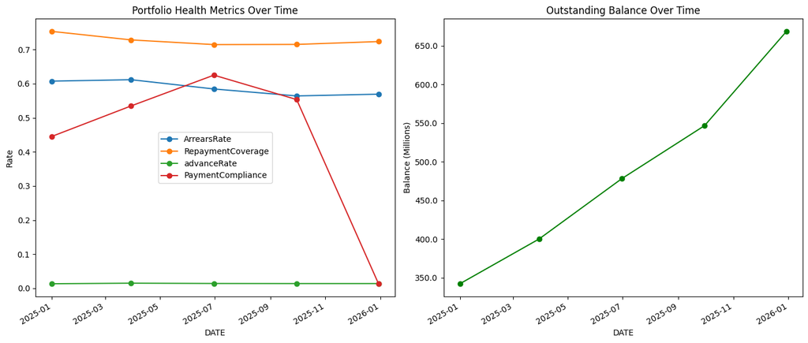

```python
import matplotlib.pyplot as plt
import matplotlib.ticker as mticker

# ---------------------------------------------
# Step 1: Calculate portfolio health metrics
# ---------------------------------------------
# - ArrearsRate: share of accounts past due
# - RepaymentCoverage: payments received ÷ balances due
# - OutstandingBalance: total loan exposure
# - AdvanceRate: proportion of balances prepaid/advanced
# - PaymentCompliance: actual vs expected payments
# ---------------------------------------------
arrears_rate = credit.groupby("DATE")["ARREARS"].apply(lambda x: (x > 0).mean())
repayment_coverage = credit.groupby("DATE")["TOTAL_PAID"].sum() / credit.groupby("DATE")["TOTAL_DUE_TODAY"].sum()
outstanding_balance = credit.groupby("DATE")["BALANCE"].sum()
advance_rate = (credit.groupby("DATE")["ADVANCE"].sum() + credit.groupby("DATE")["PREPAYMENT_AMOUNT"].sum()) / credit.groupby("DATE")["BALANCE"].sum()
payment_compliance = credit.groupby("DATE")["PAYMENT_AMOUNT"].sum() / credit.groupby("DATE")["EXPECTED_PAYMENT"].sum()

portfolio_metrics = pd.DataFrame({
    "ArrearsRate": arrears_rate,
    "OutstandingBalance": outstanding_balance,
    "RepaymentCoverage": repayment_coverage,
    "advanceRate": advance_rate,
    "PaymentCompliance": payment_compliance
})

print(portfolio_metrics)

# ---------------------------------------------
# Step 2: Visualize portfolio health trends
# ---------------------------------------------
# Left chart: repayment discipline and risk indicators
#   (ArrearsRate, RepaymentCoverage, AdvanceRate, PaymentCompliance)
# Right chart: portfolio exposure trend
#   (OutstandingBalance, formatted in millions)
# ---------------------------------------------
fig, ax = plt.subplots(1, 2, figsize=(14,6))

portfolio_metrics[[
    "ArrearsRate","RepaymentCoverage","advanceRate",
    "PaymentCompliance"]].plot(ax=ax[0], marker="o")
ax[0].set_title("Portfolio Health Metrics Over Time")
ax[0].set_ylabel("Rate")

portfolio_metrics["OutstandingBalance"].plot(ax=ax[1], marker="o",
                                             color="green")
ax[1].set_title("Outstanding Balance Over Time")
ax[1].set_ylabel("Balance (Millions)")

ax[1].yaxis.set_major_formatter(
    mticker.FuncFormatter(lambda x, _: f'{x/1_000_000:.1f}'))

plt.tight_layout()
plt.close()
```

```
            ArrearsRate  OutstandingBalance  RepaymentCoverage  advanceRate  \
DATE
2025-01-01     0.607499         342087292.0           0.753263     0.013286
2025-03-30     0.611665         399987192.4           0.728353     0.014923
2025-06-30     0.584479         478068036.4           0.714648     0.014065
2025-09-30     0.564101         546661562.8           0.715136     0.013841
2025-12-30     0.569232         668547758.2           0.723508     0.013835

            PaymentCompliance
DATE
2025-01-01           0.445495
2025-03-30           0.534812
2025-06-30           0.625038
2025-09-30           0.553470
2025-12-30           0.013367
```

## **Segment Analysis & Operational Implications**

**Segment Analysis:**

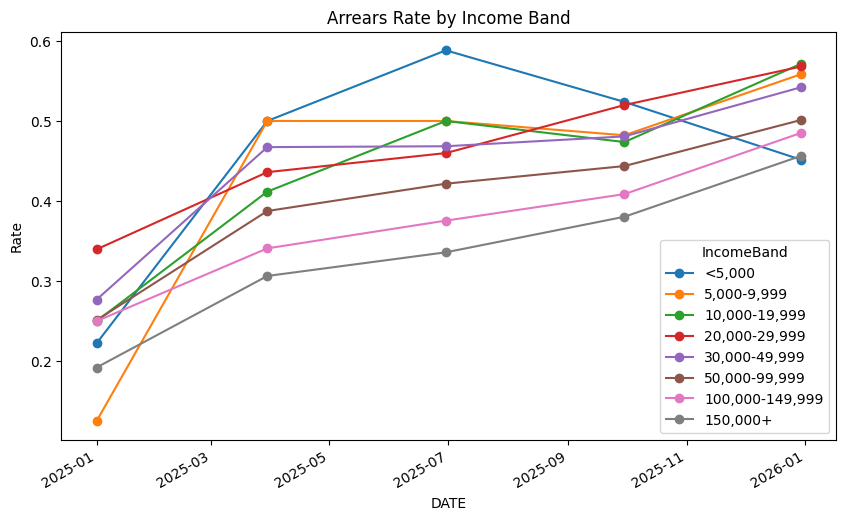

**Operational Implications:**

- Enable **targeted collections strategies** for high‑risk segments, improving repayment outcomes.
- Provide **tailored repayment support** such as flexible plans or reminders to reduce arrears.
- Inform **credit policy adjustments** by identifying vulnerable customer groups and refining lending criteria.
- Strengthen **forecasting and capital adequacy planning** through early detection of repayment stress.
- Support **proactive risk management** by combining portfolio‑level trends with segment‑specific insights.

```python
# Arrears rates by income band show higher risk among lower‑income customers.
segment_arrears = full_data.groupby(["DATE","IncomeBand"])["ARREARS"].apply(lambda x: (x>0).mean()).unstack()

segment_arrears.plot(marker="o", figsize=(10,6))
plt.title("Arrears Rate by Income Band")
plt.ylabel("Rate")
plt.close()
```

## **Collections Discipline vs Customer Satisfaction**

**Focus:**

- Compare NPS scores by **Arrears Status**
- Compare NPS scores by **Default Status**
- Compare NPS scores by **Account Status** (Active, Paid Off, etc.)

## **Collections Discipline vs Customer Satisfaction (Cont.)**

**Visual Evidence:**

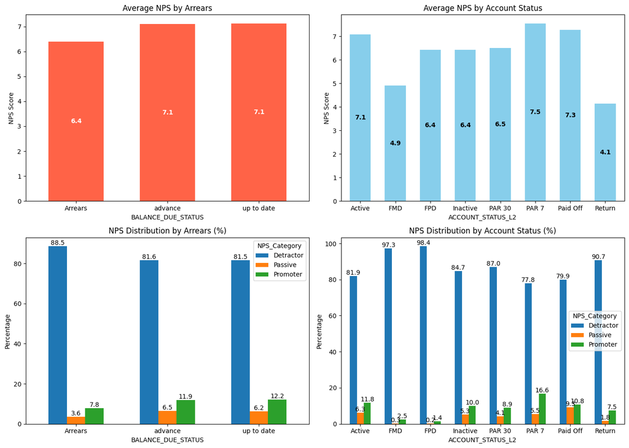

```python
# Rename NPS column for clarity
full_data.rename(columns={
    'Using a scale from 0 (not likely) to 10 (very likely), how likely are you to recommend MoPhones to friends or family?': 'NPS Score'
}, inplace=True)

# Categorize NPS scores into Promoter, Passive, Detractor
def categorize_nps(score):
    if score >= 9: return "Promoter"
    elif score >= 7: return "Passive"
    else: return "Detractor"

full_data["NPS_Category"] = full_data["NPS Score"].apply(categorize_nps)

# Average NPS by arrears status
nps_by_arrears = full_data.groupby("BALANCE_DUE_STATUS")["NPS Score"].mean()

# Average NPS by account status
nps_by_status = full_data.groupby("ACCOUNT_STATUS_L2")["NPS Score"].mean()

# NPS distribution (%) by arrears
arrears_dist = full_data.groupby("BALANCE_DUE_STATUS")["NPS_Category"].value_counts(normalize=True).unstack().fillna(0) * 100

# NPS distribution (%) by account status
status_dist = full_data.groupby("ACCOUNT_STATUS_L2")["NPS_Category"].value_counts(normalize=True).unstack().fillna(0) * 100

import matplotlib.pyplot as plt
fig, ax = plt.subplots(2, 2, figsize=(14,10))

# Plot average NPS by arrears
nps_by_arrears.plot(kind="bar", ax=ax[0,0], color="tomato", width=0.6)
ax[0,0].set_title("Average NPS by Arrears")
ax[0,0].set_ylabel("NPS Score")
ax[0,0].set_xticklabels(nps_by_arrears.index, rotation=0)
for i, val in enumerate(nps_by_arrears):
    ax[0,0].text(i, val/2, f"{val:.1f}", ha="center", va="center", color="white", fontweight="bold")

# Plot average NPS by account status
nps_by_status.plot(kind="bar", ax=ax[0,1], color="skyblue", width=0.6)
ax[0,1].set_title("Average NPS by Account Status")
ax[0,1].set_ylabel("NPS Score")
ax[0,1].set_xticklabels(nps_by_status.index, rotation=0)
for i, val in enumerate(nps_by_status):
    ax[0,1].text(i, val/2, f"{val:.1f}", ha="center", va="center", color="black", fontweight="bold")

# Plot NPS distribution by arrears
arrears_dist.plot(kind="bar", ax=ax[1,0], width=0.6)
ax[1,0].set_title("NPS Distribution by Arrears (%)")
ax[1,0].set_ylabel("Percentage")
ax[1,0].set_xticklabels(arrears_dist.index, rotation=0)
for container in ax[1,0].containers:
    ax[1,0].bar_label(container, fmt="%.1f")

# Plot NPS distribution by account status
status_dist.plot(kind="bar", ax=ax[1,1], width=0.6)
ax[1,1].set_title("NPS Distribution by Account Status (%)")
ax[1,1].set_ylabel("Percentage")
ax[1,1].set_xticklabels(status_dist.index, rotation=0)
for container in ax[1,1].containers:
    ax[1,1].bar_label(container, fmt="%.1f")

plt.tight_layout()
plt.close()
```

## **Data Quality – Limitations**

**Key challenges encountered in MoPhones’ datasets:**

- **Missing IDs** – Several sheets lack consistent unique identifiers (LoanID/CustomerID), making merges error‑prone and increasing risk of duplicates.
- **Too Many Variables** – Redundant fields and poorly defined variables add noise, slow analysis, and obscure key indicators.
- **Unstructured, Fragmented Data** – Credit snapshots, demographics, and NPS survey data are spread across multiple sheets with inconsistent formatting, making integration time‑consuming.
- **Ambiguity in Account Status Codes** – Overlapping categories (Active, Inactive, PAR 7, PAR 30, Return) are not mutually exclusive, reducing clarity in portfolio monitoring.

**Impact:** These limitations slow down monitoring, increase risk of errors, and weaken the reliability of insights drawn from the portfolio data.

## **Recommendations for Improvement**

**Proposed actions to strengthen MoPhones’ credit data structure:**

- **Introduce Consistent Unique IDs** – Standardize LoanID and CustomerID across all datasets to enable seamless merging and reduce duplication.
- **Streamline Variables** – Audit and remove unnecessary fields, focusing on core metrics such as loan performance, repayment history, arrears status, and NPS etc,.
- **Consolidate Data Capture** – Replace fragmented sheets with a single relational database or structured workbook using standardized column names and formats.
- **Standardize Account Status Definitions** – Define clear, mutually exclusive categories (Active, Paid Off, Arrears, Default) and nest PAR flags under arrears for consistency.

**Objective:** Build a cleaner, more reliable credit monitoring system that reduces analyst time spent on data preparation and supports better decision‑making.

## MoPhones Data Model for Repeatable Reporting

- **Customer** is the central entity, keyed by **LoanID**, holding demographic and segmentation fields.
- **Sales** records transactional data linked to each customer via LoanID.
- **CreditSnapshot** provides quarterly portfolio health metrics (balance, arrears, repayment status).
- **NPSResponse** captures customer satisfaction and feedback, tied back to LoanID.
- **LoanID** serves as the unifying key across all datasets, enabling consistent joins.
- This structure supports **repeatable reporting** by aligning demographics, transactions, credit outcomes, and customer experience.

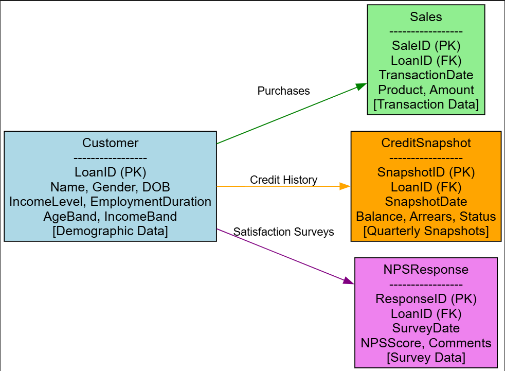

```python
# %pip install graphviz
from graphviz import Digraph
from IPython.display import SVG

# Initialize diagram with SVG output
erd = Digraph('MoPhones_ERD', format='svg')
erd.attr(rankdir='LR', size='8,5', fontname="Arial")

# Define entities with professional font, larger size, and colors
erd.node('Customer',
         "Customer\n"
         "-----------------\n"
         "LoanID (PK)\n"
         "Name, Gender, DOB\n"
         "IncomeLevel, EmploymentDuration\n"
         "AgeBand, IncomeBand\n"
         "[Demographic Data]",
         shape='box', style='filled', fillcolor='lightblue',
         fontname="Arial", fontsize="14")

erd.node('Sales',
         "Sales\n"
         "-----------------\n"
         "SaleID (PK)\n"
         "LoanID (FK)\n"
         "TransactionDate\n"
         "Product, Amount\n"
         "[Transaction Data]",
         shape='box', style='filled', fillcolor='lightgreen',
         fontname="Arial", fontsize="14")

erd.node('CreditSnapshot',
         "CreditSnapshot\n"
         "-----------------\n"
         "SnapshotID (PK)\n"
         "LoanID (FK)\n"
         "SnapshotDate\n"
         "Balance, Arrears, Status\n"
         "[Quarterly Snapshots]",
         shape='box', style='filled', fillcolor='orange',
         fontname="Arial", fontsize="14")

erd.node('NPSResponse',
         "NPSResponse\n"
         "-----------------\n"
         "ResponseID (PK)\n"
         "LoanID (FK)\n"
         "SurveyDate\n"
         "NPSScore, Comments\n"
         "[Survey Data]",
         shape='box', style='filled', fillcolor='violet',
         fontname="Arial", fontsize="14")

# Define relationships with clearer labels
erd.edge('Customer', 'Sales', label='Purchases', color='green',
         fontname="Arial", fontsize="12")
erd.edge('Customer', 'CreditSnapshot', label='Credit History', color='orange',
         fontname="Arial", fontsize="12")
erd.edge('Customer', 'NPSResponse', label='Satisfaction Surveys', color='purple',
         fontname="Arial", fontsize="12")

# Render diagram to SVG and display inline in Jupyter
erd.render('MoPhones_ERD')
```

```
'MoPhones_ERD.svg'
```